# ggplot2 : 1. Bar Graphs

```r
# install.packages(c('ggplot2’, 'gcookbook’), dependencies = TRUE)
library(ggplot2)
library(gcookbook)
```

## Making a Basic Bar Graph

```r
# method 1
ggplot(pg_mean, aes(x = group, y = weight)) +
geom_col()
```

```r
# method 2
p <- ggplot(pg_mean, aes(x = group, y = weight))
p + geom_bar(stat = 'identity')
```

- `geom_col()`, `geom_bar()` : bar graph를 그림. `geom_bar()`는 기본적으로 도수를 자체 계산하여 시각화 하는 반면, `geom_col()`은 명시적으로 변수 `y`에 지정된 값을 막대 높이로 시각화함.
- `stat = ‘identity’` : y변수를 막대의 높이로 지정
- `p <- ggplot()` : ggplot() 설정 재사용 가능

```r
str(BOD)
```

```
## 'data.frame':    6 obs. of  2 variables:
##  $ Time  : num  1 2 3 4 5 7
##  $ demand: num  8.3 10.3 19 16 15.6 19.8
##  - attr(*, "reference")= chr "A1.4, p. 270"
```

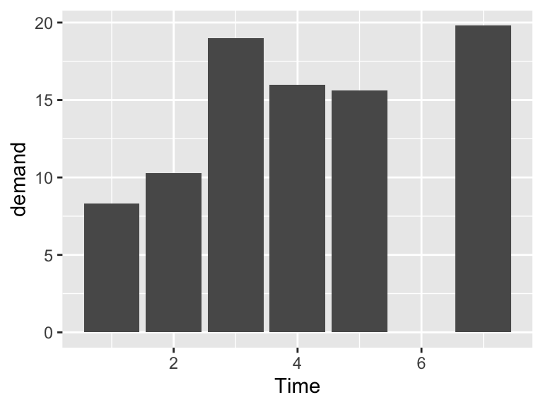

```r
ggplot(BOD, aes(x = Time, y = demand)) + geom_col()
```

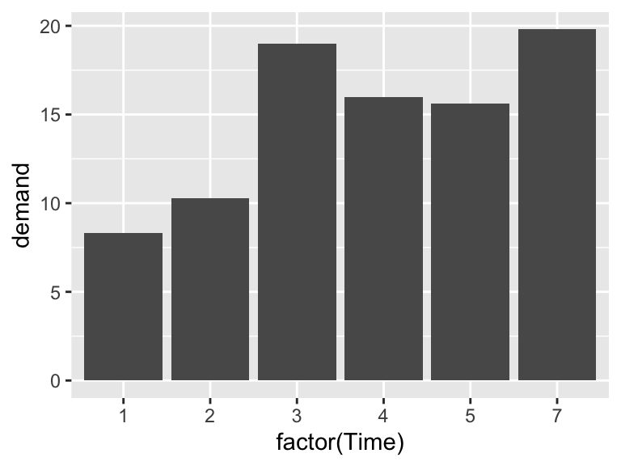

```r
ggplot(BOD, aes(x = factor(Time), y = demand)) + geom_col()
```

```r
BOD2 <- BOD
BOD2$fTime <- factor(BOD$Time)
str(BOD2)
```

```
## 'data.frame':    6 obs. of  3 variables:
##  $ Time  : num  1 2 3 4 5 7
##  $ demand: num  8.3 10.3 19 16 15.6 19.8
##  $ fTime : Factor w/ 6 levels "1","2","3","4",..: 1 2 3 4 5 6
##  - attr(*, "reference")= chr "A1.4, p. 270"
```

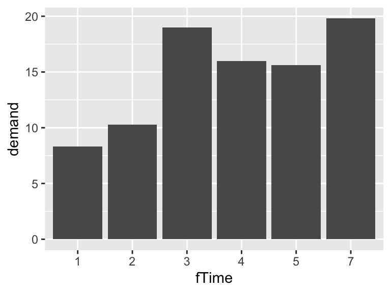

```r
ggplot(BOD2, aes(x = fTime, y = demand)) + geom_col()
```

- numeric 변수 Time을 x축으로 설정한 경우, 관측되지 않은 값 ‘6’ 에 대한 위치가 빈 공란으로 남겨짐.
- `factor( Time )`을 통해 factor 변수로 변환하게 되면 각 수치의 크기가 의미가 없어지므로 관측된 Time값에 대한 막대그래프가 빈 공란 없이 그려짐.

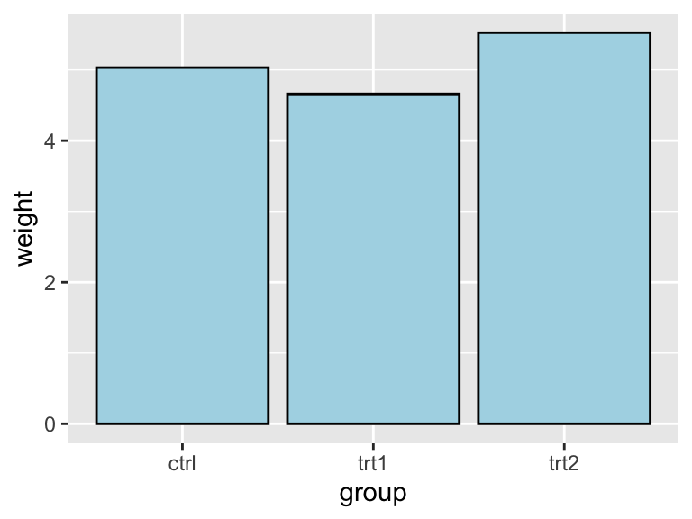

```r
ggplot(pg_mean, aes(x = group, y = weight)) +
  geom_col(fill = 'lightblue', color = 'black')
```

- `fill = ‘lightblue’` : 막대그래프 내부영역의 색상을 지정함.
- `color = ‘black’` : 막대그래프 외부둘레선의 색상을 지정함.
- **[TIP]** R에서 ‘fill’은 일반적으로 원(circle) 또는 다각형(rectangle) 내부의 색상을 설정하는데 이용되고 ‘color’는 점(point) 또는 선(line)의 색상을 설정하는데 사용됨

## Grouping Bar Together

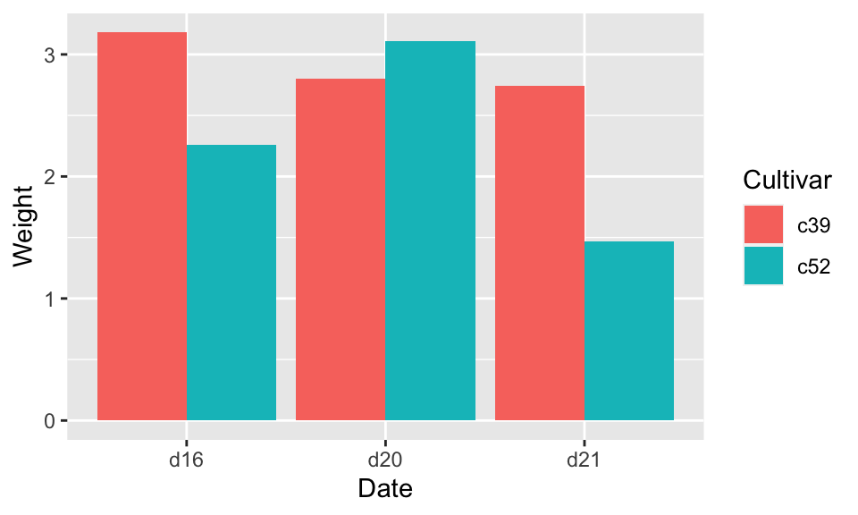

```r
p <- ggplot(cabbage_exp, aes(x = Date, y = Weight, fill = Cultivar))
p + geom_col(position = 'dodge')
```

- aesthetic 함수 (aes) 내의 `fill = Cultivar`는 Cultivar변수를 이용하여 ggplot에서 생성하는 도형의 영역 색상을 구분하도록 지정.
- `position = ‘dodge’`는 x축 값에서 두개의 막대그래프를 그리게 되는 경우 병렬(side-by-side)로 그리게 하는 옵션.
- aesthetic 함수에서의 `fill = Cultivar` 지정으로 인해 두개의 막대그래프를 그리게 해 줌. 이 경우 오른쪽에 자동으로 범례(legend)가 생성됨. 범례에 대한 처리는 **8. Legends**에서 다룸.

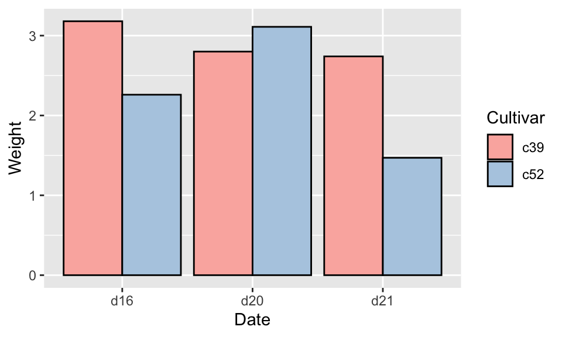

```r
p + geom_col(position = 'dodge', color = 'black') +
  scale_fill_brewer(palette = 'Pastel1')
```

- geom_bar 내의 `color = ‘black’`은 막대그래프의 둘레선 색상을 검정색으로 변환.
- `scale_fill_brewer()` 함수는 fill 에 이용되는 색상에 대한 속성을 지정함. 여기서는 `Pastel1`이라는 built-in 색상표를 이용. scale_fill_brewer 및 색상표에 대한 자세한 설명은 **10. Using Colors in Plots**에서 다룸.

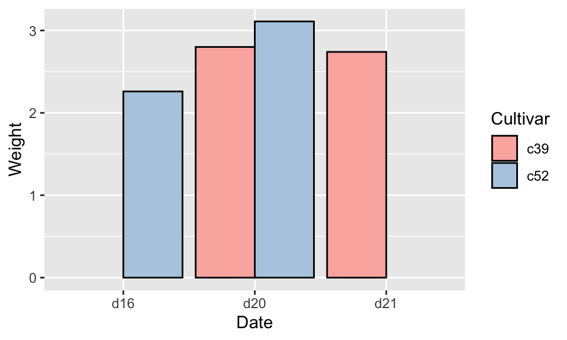

```r
ce <- cabbage_exp
ce[c(1, 6), 3] <- NA
ggplot(ce, aes(x = Date, y = Weight, fill = Cultivar)) +
  geom_col(position = 'dodge', color = 'black') +
  scale_fill_brewer(palette = 'Pastel1')
```

- (1,3), (6,3) 원소를 결측치 (missing)로 처리.
- Date = ‘d16’ & Cultivar = ‘c39’ 및 Date = ‘d21’ & Cultivar = ‘c52’ 에 대한 Weight 값이 NA로 처리.
- 이 경우 해당부분은 막대그래프에서 나타나지 않음.

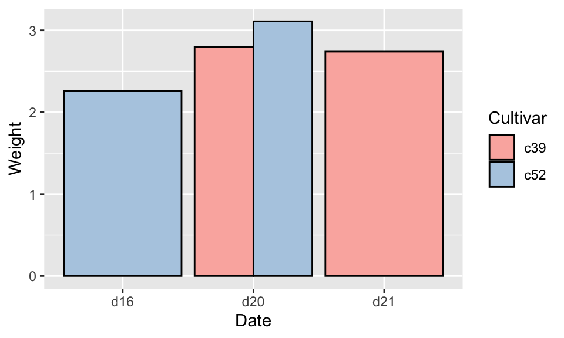

```r
ce2 <- cabbage_exp[-c(1, 6),]
ggplot(ce2, aes(x = Date, y = Weight, fill = Cultivar)) +
  geom_col(position = 'dodge', color = 'black') +
  scale_fill_brewer(palette = 'Pastel1')
```

- 데이터에서 1행 및 6행을 제거.
- Date=‘d16’ & Cultivar=‘c39’ 및 Date=‘d21’ & Cultivar=‘c52’ 에 대한 정보가 없음.
- 이 경우, Date=‘d16’에 대하여 Weight값은 Cultivar=‘c52’인 경우만 정보를 가지고 있으며 Date=‘d21’에 대하여 Weight값은 Cultivar=‘c39’인 경우만 정보가 있음. 따라서 해당 Date에 대해서는 가지고 있는 Cultivar 정보만 그림으로 나타남.

## Making a Bar Graph of Counts

```r
str(diamonds)
```

```
## tibble [53,940 × 10] (S3: tbl_df/tbl/data.frame)
##  $ carat  : num [1:53940] 0.23 0.21 0.23 0.29 0.31 0.24 0.24 0.26 0.22 0.23 ...
##  $ cut    : Ord.factor w/ 5 levels "Fair"<"Good"<..: 5 4 2 4 2 3 3 3 1 3 ...
##  $ color  : Ord.factor w/ 7 levels "D"<"E"<"F"<"G"<..: 2 2 2 6 7 7 6 5 2 5 ...
##  $ clarity: Ord.factor w/ 8 levels "I1"<"SI2"<"SI1"<..: 2 3 5 4 2 6 7 3 4 5 ...
##  $ depth  : num [1:53940] 61.5 59.8 56.9 62.4 63.3 62.8 62.3 61.9 65.1 59.4 ...
##  $ table  : num [1:53940] 55 61 65 58 58 57 57 55 61 61 ...
##  $ price  : int [1:53940] 326 326 327 334 335 336 336 337 337 338 ...
##  $ x      : num [1:53940] 3.95 3.89 4.05 4.2 4.34 3.94 3.95 4.07 3.87 4 ...
##  $ y      : num [1:53940] 3.98 3.84 4.07 4.23 4.35 3.96 3.98 4.11 3.78 4.05 ...
##  $ z      : num [1:53940] 2.43 2.31 2.31 2.63 2.75 2.48 2.47 2.53 2.49 2.39 ...
```

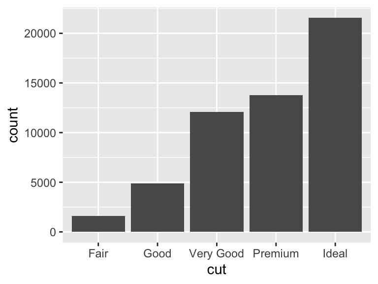

```r
ggplot(diamonds, aes(x = cut)) + geom_bar()
```

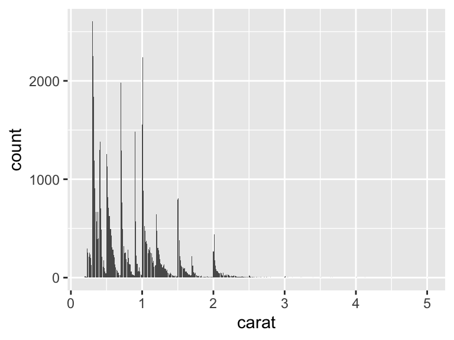

```r
ggplot(diamonds, aes(x = carat)) + geom_bar()
```

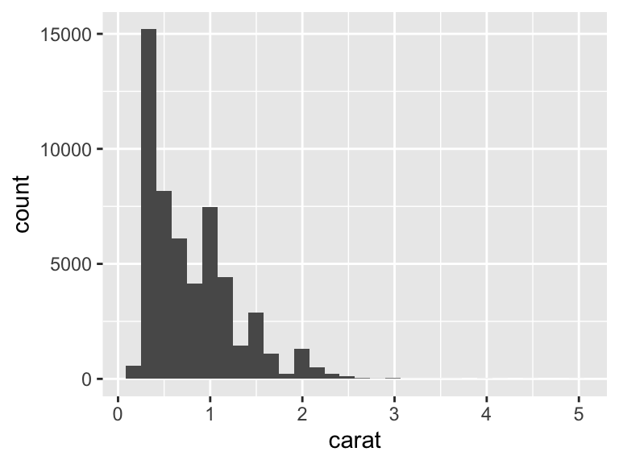

```r
ggplot(diamonds, aes(x = carat)) + geom_histogram()
```

## Using Colors in a Bar Graph

```r
str(uspopchange)
```

```
## 'data.frame':    50 obs. of  4 variables:
##  $ State : chr  "Alabama" "Alaska" "Arizona" "Arkansas" ...
##  $ Abb   : chr  "AL" "AK" "AZ" "AR" ...
##  $ Region: Factor w/ 4 levels "Northeast","South",..: 2 4 4 2 4 4 1 2 2 2 ...
##  $ Change: num  7.5 13.3 24.6 9.1 10 16.9 4.9 14.6 17.6 18.3 ...
```

```r
head(uspopchange)
```

```
##        State Abb Region Change
## 1    Alabama  AL  South    7.5
## 2     Alaska  AK   West   13.3
## 3    Arizona  AZ   West   24.6
## 4   Arkansas  AR  South    9.1
## 5 California  CA   West   10.0
## 6   Colorado  CO   West   16.9
```

```r
upc <- subset(uspopchange, rank(Change) > 40)
upc
```

```
##             State Abb Region Change
## 3         Arizona  AZ   West   24.6
## 6        Colorado  CO   West   16.9
## 10        Florida  FL  South   17.6
## 11        Georgia  GA  South   18.3
## 13          Idaho  ID   West   21.1
## 29         Nevada  NV   West   35.1
## 34 North Carolina  NC  South   18.5
## 41 South Carolina  SC  South   15.3
## 44          Texas  TX  South   20.6
## 45           Utah  UT   West   23.8
```

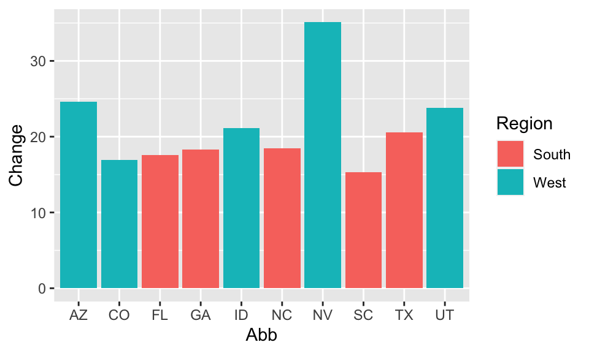

```r
ggplot(upc, aes(x = Abb, y = Change, fill = Region)) + geom_col()
```

- 함수 `str(data)`는 R data 객체의 구조적 특성(자료의 개수, 변수의 개수, 각 변수명 및 자료형 등)을 보여줌.
- 함수 `head(data)`는 data 객체의 최초 6개 행을 나열함. `tail(data)`은 마지막 6개 행을 보여줌.
- 함수 `subset(data, condition)`은 data에서 condition을 만족하는 행을 선택하여 data frame 형태로 결과를 넘김.
- `fill = Region` 은 변수 Region 값에 따라 막대그래프의 색상을 표현함.

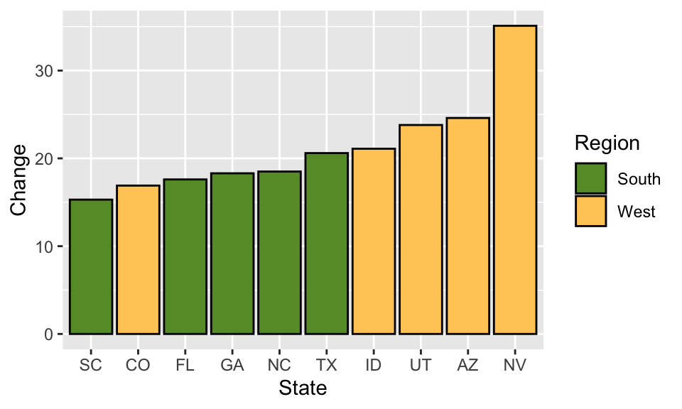

```r
ggplot(upc, aes(x = reorder(Abb, Change), y = Change, fill = Region)) +
  geom_col(color = 'black') +
  scale_fill_manual(values = c('#669933', '#FFCC66')) +
  xlab('State')
```

- 함수 `reorder(var1, var2)` 는 var1을 var2의 기준으로 순서를 정렬함.
- `scale_fill_manual`을 이용하여 fill의 색상을 정함. #RRGGBB는 RGB색상코드임.
- `xlab(‘State’)`을 이용하여 x축 label을 State으로 지정함.

## Coloring Negative and Positive Bars Differently

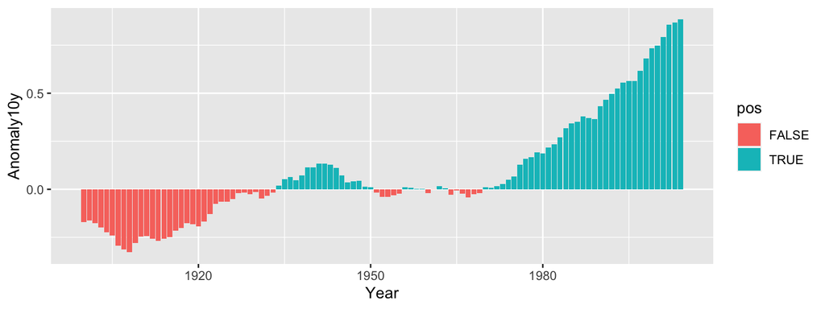

```r
csub <- subset(climate, Source == 'Berkeley' & Year >= 1900)
csub$pos <- csub$Anomaly10y >= 0
p <- ggplot(csub, aes(x = Year, y = Anomaly10y, fill = pos))
p + geom_col(position = 'identity')
```

- 데이터 csub은 climate 중에서 Source 값이 ‘Berkely’이고 Year 값이 1900보다 크거나 같은 값을 가지는 자료만을 포함.
- 변수 pos는 Anomaly10y가 음이 아닌 수이면 TRUE, 음의 값을 가지면 FALSE를 가짐

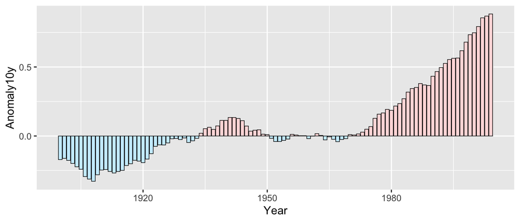

```r
p <- ggplot(csub, aes(x = Year, y = Anomaly10y, fill = pos))
p + geom_col(position = 'identity', color = 'black', size = 0.25) +
  scale_fill_manual(values = c('#CCEEFF', '#FFDDDD'), guide = FALSE)
```

- 옵션 `size = 0.25`는 막대그래프의 막대경계선의 굵기를 설정.
- 옵션 `guide = FALSE`는 legend를 출력하지 않게 함.

## Adjusting Bar Width and Spacing

```r
p <- ggplot(pg_mean, aes(x = group, y = weight))
p + geom_col() # default width=0.9
```

[output not shown]

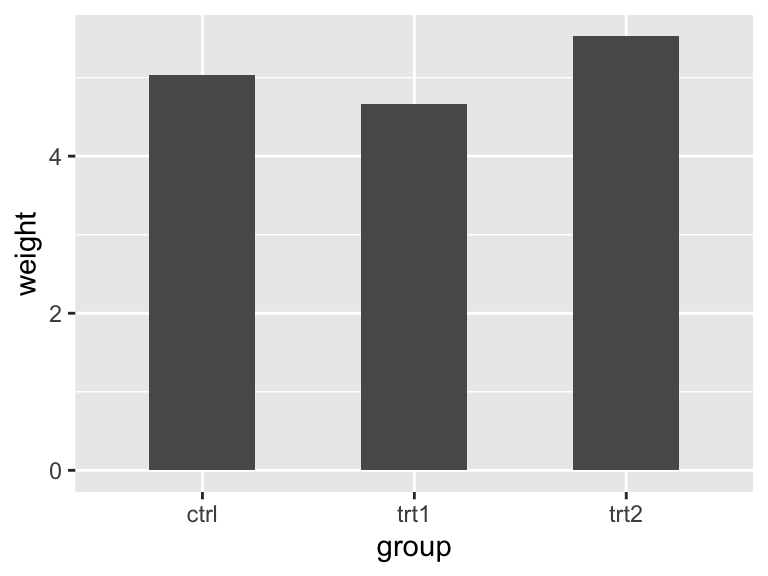

```r
p + geom_col(width = 0.5)  # narrower
```

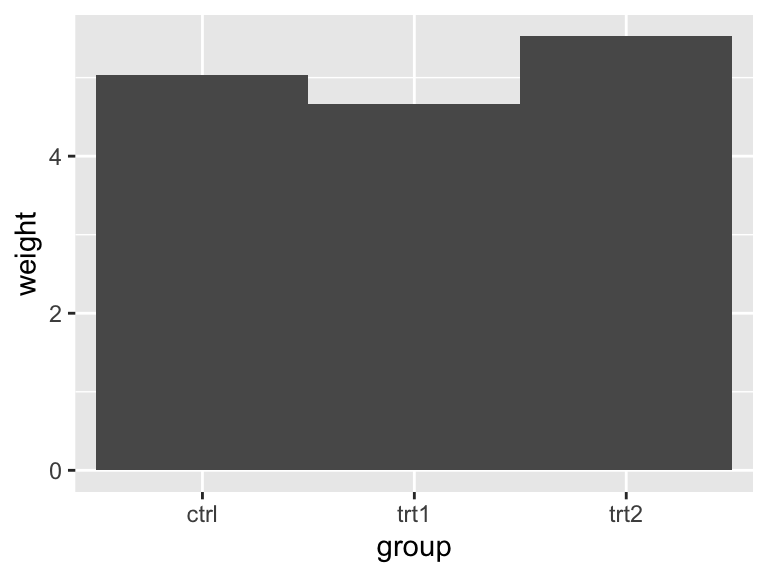

```r
p + geom_col(width = 1)  # wider
```

- 막대그래프의 폭은 디폴트가 `width = 0.9`이며 값이 클수록 넓어지며 작을수록 좁아진다.

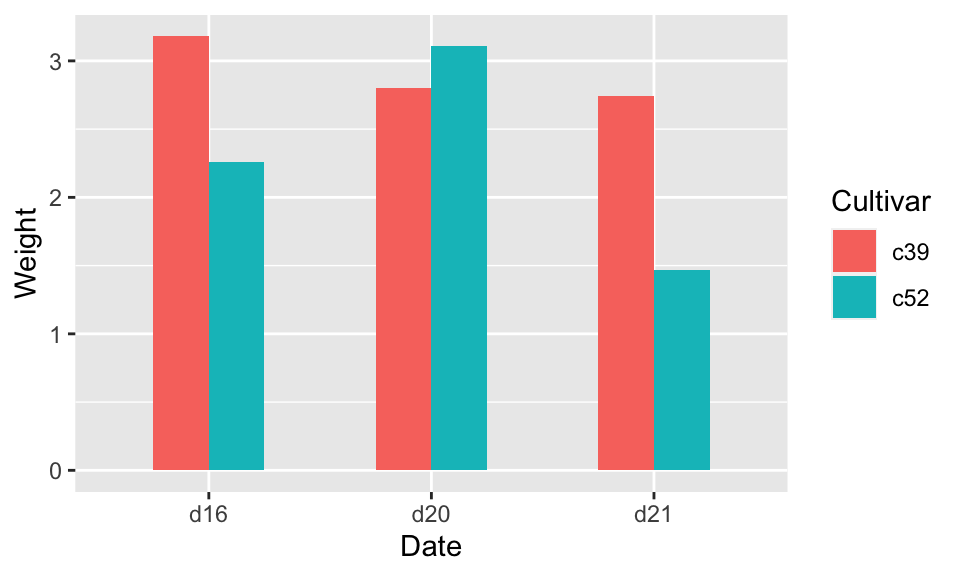

```r
p <- ggplot(cabbage_exp, aes(x = Date, y = Weight, fill = Cultivar))
p + geom_col(width = 0.5, position = 'dodge')
```

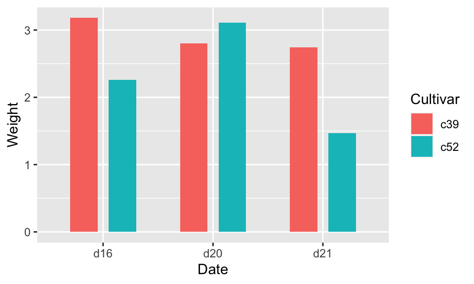

```r
p + geom_col(width = 0.5, position = position_dodge(0.7))
```

- 옵션 `position = ‘dodge’`는 x축 하나의 값에 여러개의 그룹으로 나누어진 정보를 side-by-side로 나열함.
- `position = ‘dodge’`는 `position = position_dodge(value of width)`와 동일. 수치가 증가하면 두 막대간의 공간은 넓어짐.

## Making a Stacked Bar Graph

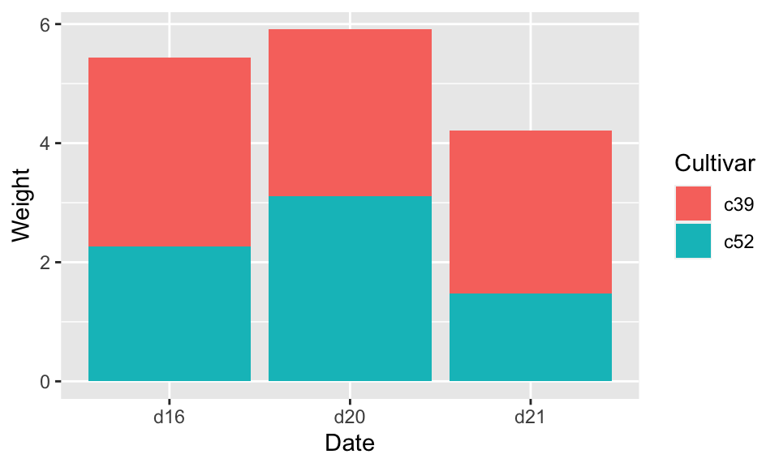

```r
p <- ggplot(cabbage_exp, aes(x = Date, y = Weight, fill = Cultivar))
p + geom_col()
```

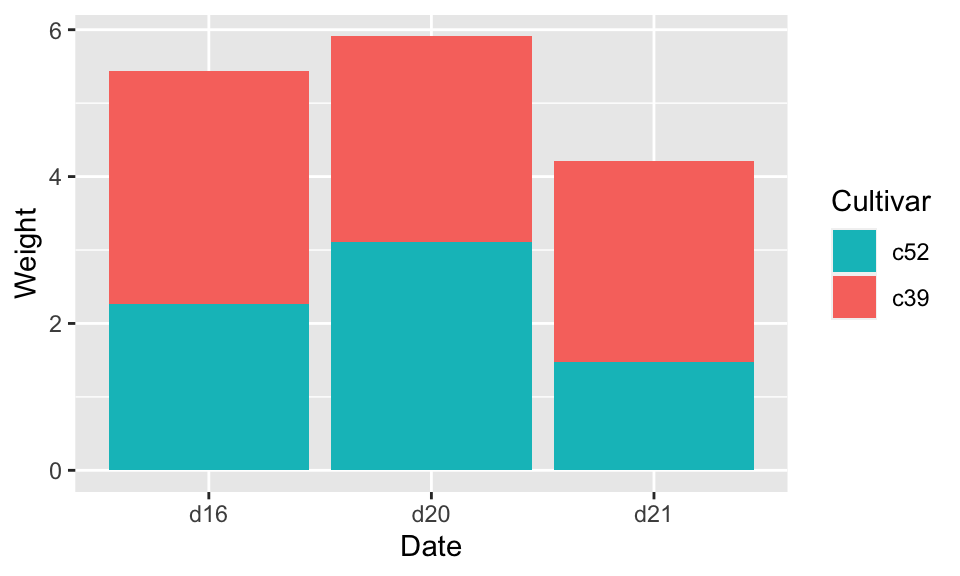

```r
p + geom_col() + guides(fill = guide_legend(reverse = TRUE))
```

- Stacked 막대그래프를 위해 옵션 `position = ‘dodge’`를 제거.
- 함수 `guide_legend(reverse)`는 legend의 순서를 역순으로 변경함.

## Adding Labels to a Bar Graph

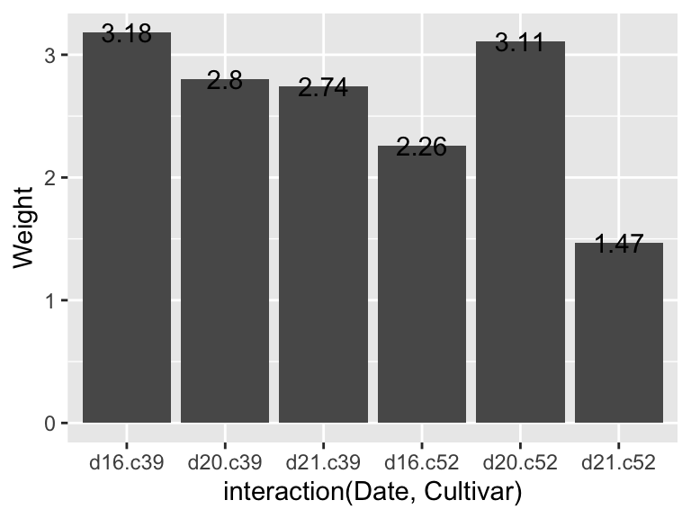

```r
p <- ggplot(cabbage_exp, aes(x = interaction(Date, Cultivar), y = Weight)) +
  geom_col()
p + geom_text(aes(label = Weight))
```

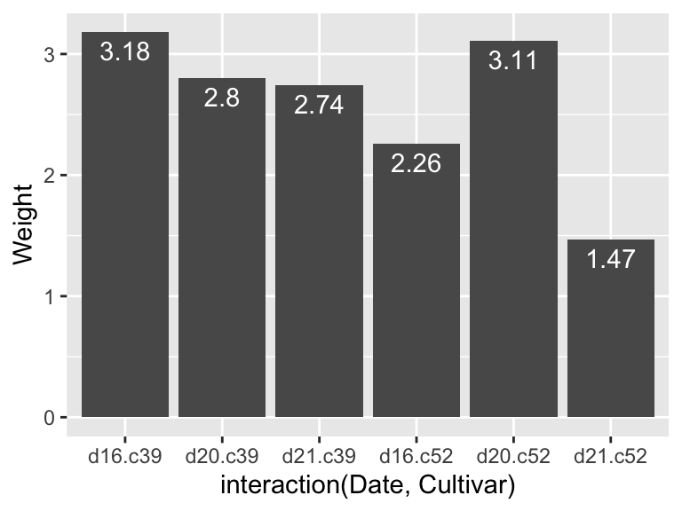

```r
p + geom_text(aes(label = Weight), vjust = 1.5, color = 'white')
```

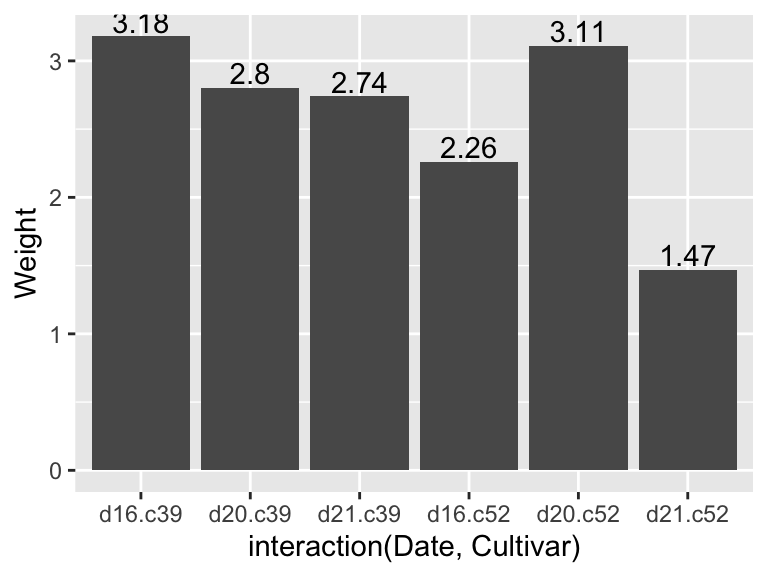

```r
p + geom_text(aes(label = Weight), vjust = -0.2)
```

- 함수 `interaction(Date, Cultivar)`는 두 변수의 조합을 생성함.
- `geom_text()` 내의 aesthetic 함수의 `label = Weight`은 변수 Weight의 값을 text label로 출력. 출력시 위치는 ggplot( aes() )에서 지정한 x, y 좌표에 놓임.
- `vjust`는 text의 상하위치를 조정함. 양수값일때 아래, 음수값일때 위로 위치조정.